# Open Science, Mentorship, Outreach, and Teaching

*We can take it upon ourselves to build an inclusive community for teams to collaborate with and learn from. Internally-driven investment in professional development extends the impact of a team member and takes the weight off the organization’s experts as new users are able to take on more tasks.*

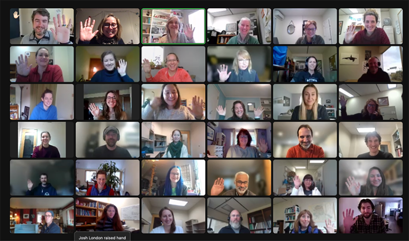

*A screenshot of the 2022 AFSC Fall Openscapes cohort over zoom.*

## Teaching

**Teaching assistant of UW FISH 572: Principles and applications of fisheries-independent surveys.**. 2026. N/A.

**NOAA Fisheries Alaska Bottom Trawl Survey public data products**. 2024. EH Markowitz.

- Guest lecturer in Dr. Caleb M. Trujillo’s BIS 232 Introduction to Data Visualization Course, University of Washington Bothell
- Introduced students to open science data products produced for AFSC bottom trawl surveys

**Automated Scientific Reporting in R: Basics to Production**. 2023. EH Markowitz.

- 2023 UMass Dartmouth QuantFish Seminar Workshop
- Links: [Recording](https://umassd.zoom.us/rec/share/nkmHvFjlp_0np6KMW4gZn4eu3DyFa9_AkdazdWC14I6lxVw_Dp2lWEyey8PAwsus.TFFmSt0YtE1JHySK), [GitHub Repo](https://github.com/EmilyMarkowitz-NOAA/automated-reporting-ex)

**Co-teacher and co-organizer for conference short GitHub course**. 2022. 2022 Women in Statistics and Data Science Conference.

- Git-ting It Together: Learn to Use Git and GitHub for Your Projects
- Co-taught and co-organized with Eli Holmes
- [Short course description](https://ww2.amstat.org/meetings/wsds/2022/courses.cfm)
- [GitHub Repository](https://github.com/RWorkflow-Workshops/WSDS-StLouis)

**Co-teacher and Co-organizer**. 2021. NOAA Fisheries Alaska Fisheries Science Center.

- Co-host and organize a 5-week entry-level R-Users workshop for 15 coworkers in the AFSC RACE groundfish assessment program. Developed a curriculum, lesson plans, and assignments.
- [Lesson Website](https://emilymarkowitz-noaa.github.io/FishR101/index.html)

**Co-teacher and Co-organizer**. 2020. NOAA Fisheries Office of Science and Technology Division of Economics and Social Analysis.

- Co-hosted a Workshop for Social Scientists for over 60 participants from across the country and across centers
- [Lesson Website](https://emilymarkowitz-noaa.github.io/RWorkshopForSocialScientists/)

**ArcGIS Teaching Assistant**. 2015. Sustainability Studies Program, Stony Brook University.

- Introduction to ArcGIS, taught by Professor Maria Brown.
- Worked with students to develop multi-map projects aimed at answering questions in hydrology, weather, climate change, and marine science for unique final projects in ArcGIS.
- Provided comments and assessments of presentations, quizzes, and homework assignments.
- Held office hours and provided computer assistance.

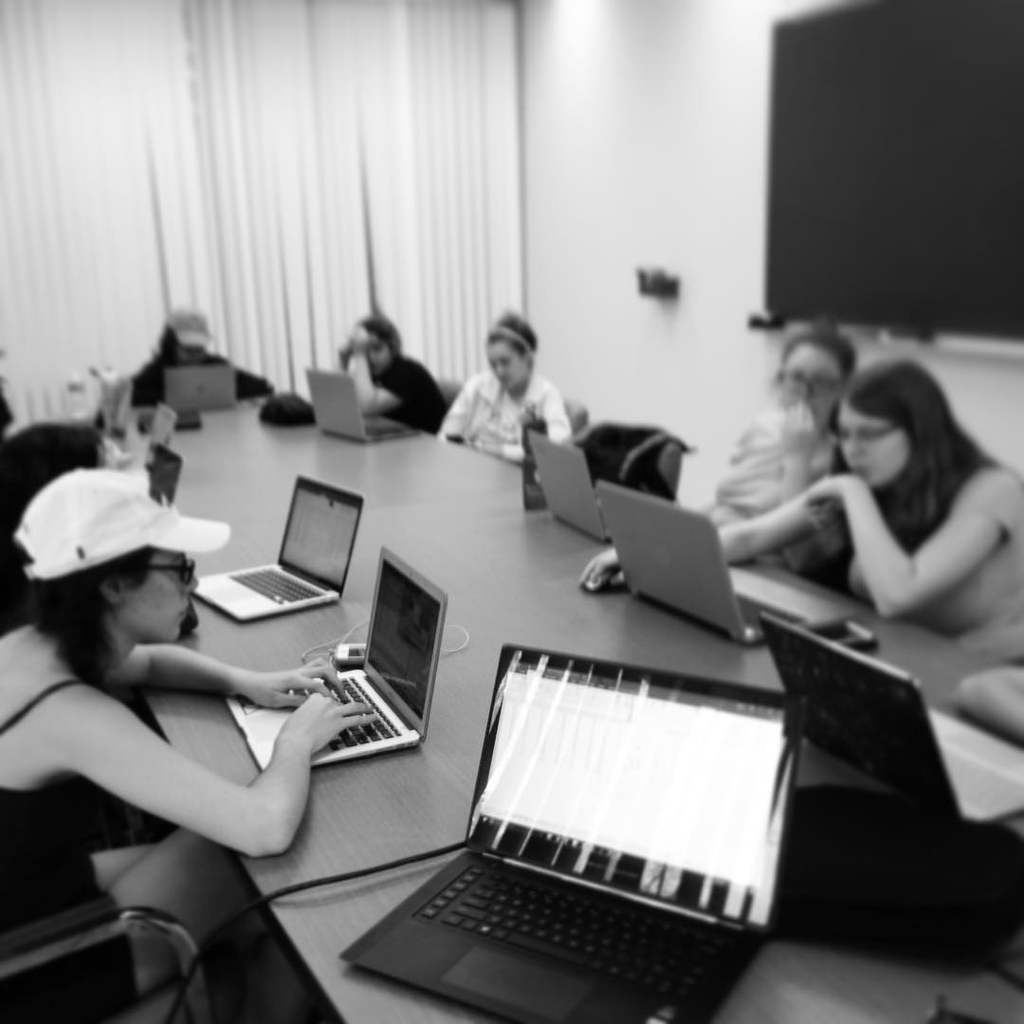

*Stony Brook WISE (Women in Science and Engineering) working up some of the day’s data from our mini-study on blue crab temperature-dependent aerobic and anaerobic metabolism.*

## Outreach

**Guest scientist**. 2024. EH Markowitz.

- Stony Brook University’s Society for Women in Marine Science SWMSpiration Series
- Discussed career path and insights from time at alma mater.

**What ecosystem studies mean for your dinner plate: NOAA Alaska Bottom Trawl Fisheries Survey**. 2024. EH Markowitz.

- Mad Science Improv — Bandit Improv Comedy Theater
- Introduced audiance to the AFSC’s Groundfish Assessment program’s fisheries-independant bottom trawl surveys and how this work is used in fisheries management. Presented 8 minute talk and an improv team performed skits based on what they learned from the presentation.
- Links: [Theatre information](https://www.bandittheater.org/mad-science)

**What does a Fisheries Researcher Do?**. 2022. Markowitz, EH.

- NOAA Live! Alaska Seminar Series
- Links: [Recording](https://www.youtube.com/watch?v=brGFp4624Xw&list=PLAQnGWBDUJgBegaPXp_lIxbWBU0wqh-oO&index=9), [NOAA Live! Alaska](https://www.fisheries.noaa.gov/alaska/outreach-and-education/noaa-live-alaska-season-2-2021-22)

**Counting Fish in Alaska!**. 2021. Diversity in STEM - Let’s Talk Science Symposium.

- Presented to students in grades 3-8 from across Montreal, Quebec, Canada about NOAA Fisheries groundfish surveys in Alaska.

**Skype and Scientist Visiting Scientist**. 2018 - Present. Remote.

- 30+ schools across the country K-12

**Science Festival Booth Presenter**. 2018. Brennan, N, C Neidig, P Caldentey, EH Markowitz, K Leber.

- Used the Science on Sphere (SOS) to share relationships between temperature, climate change, and changes in fish distributions.

**Presenter**. 2018. Smithsonian National Museum of Natural History’s Expert is in Program.

- Hosted a table in the Smithsonian Natural History Museum Ocean Hall and engage with patrons about fisheries management.

**WISE Program Assisting Researcher**. 2016 - 2017. School of Marine and Atmospheric Sciences, Stony Brook University.

- Stony Brook WISE (Women in Science and Engineering) working up some of the day’s data from our mini-study on blue crab temperature-dependent aerobic and anaerobic metabolism.

**Plastic Pollution Outreach Program Organizer**. 2014. Coastal Steward Long Island.

- Wrote, designed, and ran an outreach initiative teaching local elementary and middle school students about the global marine plastic pollution problem with Coastal Steward

[figure not shown]

*Visiting scientist at the Smithsonian National Museum of Natural History’s Expert Is In Program. There, we talked about about how fish are caught in recreational and commercial fisheries, fishing gear, and sustainable seafood.*

## Mentoring

**Mentor**. 2024. The William M. Lapenta - NOAA Student Internship Program.

- Mentored Student building R Shiny application to show survey progress and bottom temperatures from bottom trawl surveys. Student also joined survey team on the 2024 eastern Bering Sea bottom trawl survey.
- Links: [Link](https://vlab.noaa.gov/web/lapenta-internship-program)

**Capstone Co-mentor**. 2020 - 2021. University of Washington School on the Environment Undergraduate Capstone Program.

- Mentored student investigating the purple-orange sea star and bivalve climate change-driven distribution changes in Alaska’s eastern Bering Sea.

**High School STEM Competition Mentor and Volunteer**. 2019 - 2020. Blacks in Government.

- Mentor to student participant and assisted with marketing for the NOAA Chapter High School STEM Competition.

**Graduate Peer Mentor**. 2017. School of Marine and Atmospheric Sciences, Stony Brook University.

- Helped troubleshoot seabird telemetry home range metrics and marine mammal bycatch modeling

**High School Student Mentor**. 2016. Dr. Janet Nye, Quantitative Fisheries Ecology Laboratory, Stony Brook University.

- Mentored high school student assisting on assessment of Black Sea Bass (*Centropristis striata*) winter survival on the NE US shelf using MATLAB

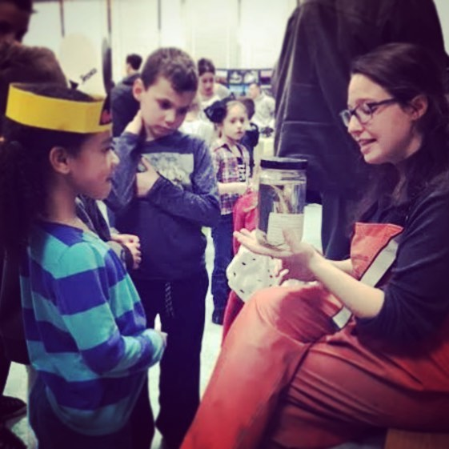

*Talking to students at the Wenonah elementary school science fair about some fish most people never get to see.*

## Open Science

**National Openscapes Mentor Group for NOAA Fisheries**. 2023 - Present. NOAA Fisheries Alaska Fisheries Science Center.

- Working to support a national-level, 3-year cohort with mentors across NOAA Fisheries and Openscapes.
- [Openscapes Website](https://www.openscapes.org/)
- [AFSC-Openscapes Landing Page](https://www.fisheries.noaa.gov/alaska/science-data/alaska-fisheries-science-center-openscapes-cohorts)
- [nmfs-opensci GitHub Organization](https://nmfs-openscapes.github.io/)
- [Blog](https://openscapes.org/blog/2024-01-24-nmfs-mentors/)

**Co-organizer and co-host for the Fall 2022 AFSC Openscapes Workshop**. 2022. NOAA Fisheries Alaska Fisheries Science Center.

- Openscapes training for the center was funded for a second round with Megsie Siple and Josh London.
- [AFSC News Article: Making Inroads to Open Science](https://www.fisheries.noaa.gov/feature-story/2022-fall-openscapes-champion-cohort-makes-inroads-open-science)
- [AFSC Website Cohort Digest](https://www.fisheries.noaa.gov/alaska/science-data/2022-fall-alaska-fisheries-science-center-openscapes-cohort)
- [Openscapes: AFSC Blog Digest Post](https://www.openscapes.org/blog/2023/02/16/2022-noaa-afsc-fall/)
- [Openscapes Nation-Wide Cohort Blog Post](https://www.openscapes.org/blog/2023/01/24/2022-noaa-nmfs-fall/)

**Co-organizer and co-host for the Winter 2022 AFSC Openscapes Workshop**. 2022. NOAA Fisheries Alaska Fisheries Science Center.

- Co-wrote a proposal to bring the inaugural Openscapes training workshops to AFSC with Megsie Siple and Josh London
- [AFSC Website Cohort Digest](https://www.fisheries.noaa.gov/alaska/science-data/2022-winter-alaska-fisheries-science-center-openscapes-cohort)
- [nmfs-opensci Workshop Digest](https://nmfs-openscapes.github.io/cohorts/AFSC-win2021.html)
- [Openscapes: AFSC Blog Digest Post](https://www.openscapes.org/blog/2022/04/07/afsc-supportive-forum/)

**Co-organizer of the NMFS-wide R Users Group and GitHub Organization**. 2021 - Present. NOAA Fisheries Alaska Fisheries Science Center.

- Organize meetings and speakers and foster the open science-R community across NMFS.
- [NMFS-R-UG GitHub Organization](https://nmfs-opensci.github.io/NMFS-R-UG/)
- [nmfs-opensci GitHub Organization](https://github.com/nmfs-opens)

[© Copyright 2024 Emily Markowitz](https://github.com/EmilyMarkowitz-NOAA/)